# VIQ - Laboratorio 5

2021-04-30

### Obiettivi

1. Usare ggplot per creare grafici

### Strumento

R ed RStudio, in particolare la libreria ggplot (parte di tidyverse):

### Dataset

Utilizziamo il dataset pubblico sui dati ISTAT con periodo di riferimento GENNAIO-FEBBRAIO 2021, pubblicati in data 06 APRILE 2021:

https://www.istat.it/it/archivio/256254

Usiamo il dataframe ripulito secondo le indicazioni dello scorso laboratorio. Il file `TidyIstat.R` contiene il codice per scaricare e ripulire i dati, che vengono salvati in `istat_occupazione.RDS` (formato compresso di R) che può essere letto tramite il metodo `read_rds()`.

```r
istat <- read_rds("istat_occupazione.RDS")
#rds formato piu compresso
istat
```

| anno | mese | Sesso | data | attivita | occupazione | disoccupazione | disoccupazione.giovani |
| --- | --- | --- | --- | --- | --- | --- | --- |
| 2004 | Gennaio | MF | 2004-01-31 | 0.6251241 | 0.5726618 | 0.08318213 | 0.2302467 |
| 2004 | Gennaio | M | 2004-01-31 | 0.7423701 | 0.6949558 | 0.06325251 | NA |
| 2004 | Gennaio | F | 2004-01-31 | 0.5089549 | 0.4514910 | 0.11225915 | NA |
| 2004 | Febbraio | MF | 2004-02-29 | 0.6246365 | 0.5738719 | 0.08059644 | 0.2243787 |
| 2004 | Febbraio | M | 2004-02-29 | 0.7426258 | 0.6955450 | 0.06274963 | NA |
| 2004 | Febbraio | F | 2004-02-29 | 0.5077213 | 0.4533064 | 0.10669832 | NA |
| 2004 | Marzo | MF | 2004-03-31 | 0.6280778 | 0.5760631 | 0.08194947 | 0.2313517 |
| 2004 | Marzo | M | 2004-03-31 | 0.7463560 | 0.6973115 | 0.06492869 | NA |
| 2004 | Marzo | F | 2004-03-31 | 0.5108715 | 0.4559136 | 0.10680558 | NA |
| 2004 | Aprile | MF | 2004-04-30 | 0.6229403 | 0.5717253 | 0.08147783 | 0.2389849 |

[output cut: 608 more lines]

- Mostrare l’andamento del tasso di disosccupazione di Femmine, Maschi, e Generale.
  - Usare prima dei punti colorati in modo diverso:

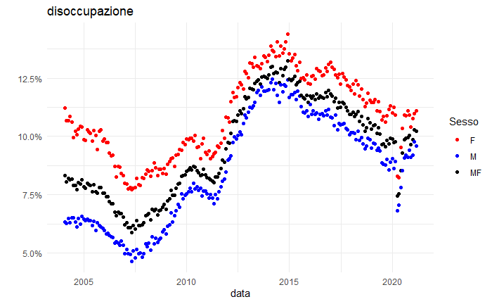

```r
## DA COMPLETARE
istat%>%
  ggplot(aes(x=data, y=disoccupazione, group=Sesso, color=Sesso))+
  geom_point()+
   scale_color_manual(values=c("red","blue", "black"))+
  ggtitle("disoccupazione")+
  ylab("")+
  scale_y_continuous(labels = scales::percent_format())+
  theme_minimal()
```

```r
#evidente che con un andamento questo tipo di visualizzazione non è l'ideale, anche rendendo i punti piu piccoli
#soprattutto dove ci sono oscillazioni, difficile capire che direzione prendono, quale punto viene prima, quale viene dopo
```

- e poi usare delle linee:

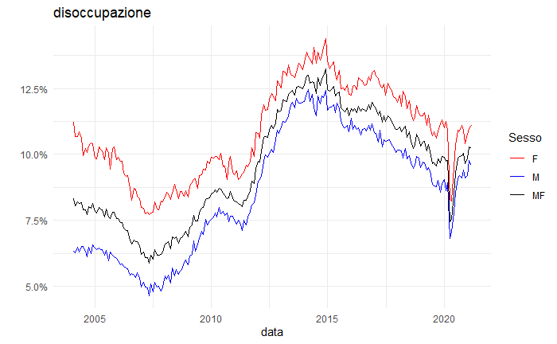

```r
## DA COMPLETARE
istat%>%
  ggplot(aes(x=data, y=disoccupazione, group=Sesso, color=Sesso))+
  geom_line()+
   scale_color_manual(values=c("red","blue", "black"))+
  ggtitle("disoccupazione")+
  ylab("")+
  scale_y_continuous(labels = scales::percent_format())+
  theme_minimal()
```

```r
 # facet_wrap(~Sesso)
#problema dato da grosso picco discendente del lockdown 2020
```

- Riflessione: quale dei due tipi di layer è più adatto? Più adatto l’uso della linea poiche abbiamo veramente tanti dati e quindi troppi punti da andare a disegnare, i quali non rendono neanche troppo facile capire l’andamento del tasso di disoccupazione che è il vero focus di questo grafico

## Scale

La visualizzazione può essere personalizzata prima di tutto tramite delle opportune scale che fanno corrispondere i valori delle variabili a delle diverse caratteristiche visuali.

### Scala colore

- Modificare il diagramma a linee precedente in modo che i colori utilizzati per Donne, Uomini e Generale siano rispettivamente rosa, blu e grigio (`pink`,`skyblue`, `gray50`).

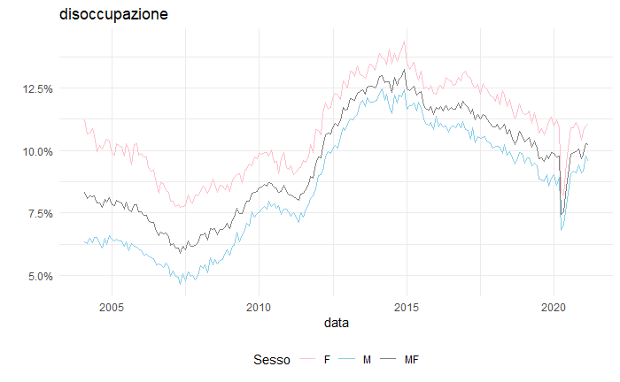

```r
## DA COMPLETARE
linee<-istat%>%
  ggplot(aes(x=data, y=disoccupazione, group=Sesso, color=Sesso))+
  geom_line()+
  #gray100 ha luminosita al massimo
  #gray10 luminosita al 10% e infatti è molto piu scuro
   scale_color_manual(values=c("pink","skyblue", "gray50"))+
  ggtitle("disoccupazione")+
  ylab("")+
  scale_y_continuous(labels = scales::label_percent())+
  theme_minimal()+
  theme(legend.position = "bottom")
#theme aggiunta dal prof

linee
```

```r
#posso salvare il plot in una variabile (linee qui)
```

### Altre scale

È possibile utilizzare delle scale per qualsiasi aspetto estetico, ad esempio per `geom_line()` è possibile specificare l’estetica `linetype` per il tipo di linea:

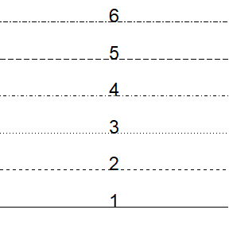

- Modificare il grafico del punto precedente in modo che i valori per Maschi e Femmine siano a tratto continuo, mentre quelli Generali siano a punto e linea.
  - Suggerimento: si utilizzi la funzione `scale_linetype_manual()`.

```r
## DA COMPLETARE
#per sapere in che ordine si applicano, faccio
levels(istat$Sesso)
```

```
[1] "F"  "M"  "MF"
```

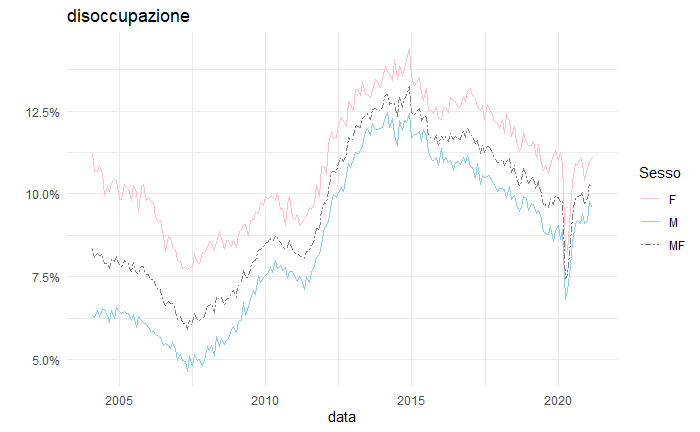

```r
#cosi capisco che vengono prima femmine, poi maschi, poi generale

#oltre i 6 livelli sono difficili da percepire
#a 4 ci arriviamo tutti, 5 e 6 gia piu difficili, oltre non riusciremo a distinguere
istat%>%
  ggplot(aes(x=data, y=disoccupazione, group=Sesso, color=Sesso, linetype=Sesso))+

   scale_color_manual(values=c("pink","skyblue", "gray50"))+
   geom_line()+ #aes(linetype=Sesso) potevi metterlo pure qui dentro
  #puoi indicare il tipo di linea anche come numeri
   scale_linetype_manual(values=c(1,1,6))+
 # scale_linetype_manual(values=c("solid", "solid", "dotdash"))+
  ggtitle("disoccupazione")+
  ylab("")+
  scale_y_continuous(labels = scales::percent_format())+
  theme_minimal()
```

```r
#appunti su aes
#aes sembra un comando che serve a dire: modello un "aspetto estetico" in base alla variabile che ti dico
#modello la x sui dati
#la y sulla disoccupazione
#il colore in base al sesso, dicendogli questo avrò 3 colori diversi perche ci sono 3 sessi diversi. Poi dopo con la scala, gli dico quali colori adottare
#linetype=sesso significa che il tipo di linea è espresso in funzione del sesso, se non specifico la scala da usare userà in modo automatico 3 tipi diversi
```

### Scala posizione

La scala verticale rappresenta dei tassi (<1) che potrebbero essere rappresentati meglio come percentuali. È possibile utilizzare la funzione `scale_y_continuous()` per specificare come stampare le etichette. In particolare è possibile utilizzare il parametro `labels` a cui passare una funzione che - prende i valori corrispondenti alle etichette - resituisce l’etichetta (ad es. 0.12 dovrebbe diventare “12%”)

- Modificare il grafico precedente in modo da stampare correttamente le percentuali sull’asse y.
  - Suggerimento: è possibile scrivere esplicitamente la funzione oppure usare `scales::percent` che è una funzione già definita.

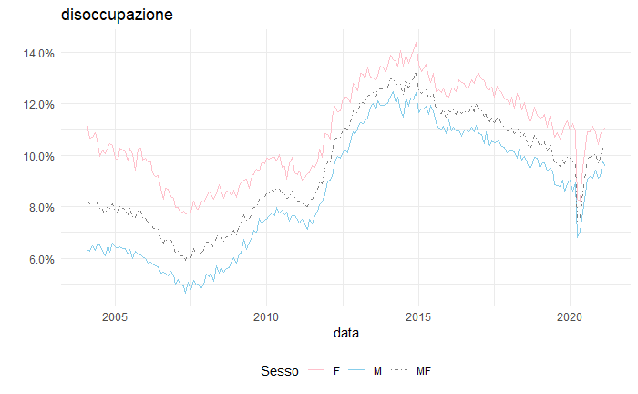

```r
## DA COMPLETARE
istat%>%
  ggplot(aes(x=data, y=disoccupazione, group=Sesso, color=Sesso, linetype=Sesso))+

   scale_color_manual(values=c("pink","skyblue", "gray50"))+
   geom_line()+ #aes(linetype=Sesso) potevi metterlo pure qui dentro
  scale_linetype_manual(values=c("solid", "solid", "dotdash"))+
  ggtitle("disoccupazione")+
  ylab("")+
  #con breaks riesco a dire le cifre che voglio vedere io sull'asse delle y
  scale_y_continuous(breaks=c(0.04,0.06,0.08,0.10,0.12,0.14),
                     labels = scales::label_percent())+
  #scale_y_continuous è la scala di default per l'estetica y. labels è un parametro
  theme_minimal()+
  theme(legend.position = "bottom")
```

```r
#posso usare funzione percentuale scritta da me, meglio label_percent() piuttosto che percent_format()
```

## Direct labeling

- Rimuovere la legenda e sostituirla con un direct labeling.
  - Suggerimento: per rimuovere la legenda legata ad una scale, usare `guide="none"` nella funzione di scala
  - Suggerimento: per allineare il testo alla destra dell’estremo destro delle linee, è possibile usare il parametro `hjust=0`, ed il parametro `nudge_x` per distanziarlo ulteriormente.

```r
## DA COMPLETARE
#guide="none" va messo sia nella scala del colore che della linea, altrimenti se lo fai solo in uno, noti che rimane una legenda parziale, che prende info da dove guide="none" non c'è ancora. Notato anche che non è possibile metterlo a livello globale
rightmost<-istat%>%
 group_by(Sesso)%>%
  summarize(disoccupazione=last(disoccupazione), data=last(data))
rightmost
```

| Sesso | disoccupazione | data |
| --- | --- | --- |
| F | 0.11101640 | 2021-02-28 |
| M | 0.09576675 | 2021-02-28 |
| MF | 0.10224663 | 2021-02-28 |

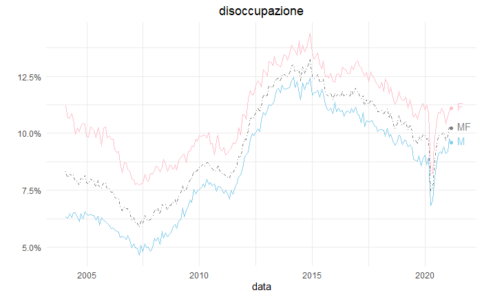

```r
#rightmost potevi anche farlo con istat%>% filter(data=max(data))
#cosi come hai fatto dopo, cosi hai i dati di prima
#ha bisogno che rightmost abbia anche la data che in effetti è la x, altrimenti non sa dove posizionarlo

istat%>%
  ggplot(aes(x=data, y=disoccupazione, group=Sesso, color=Sesso, linetype=Sesso))+

   scale_color_manual(values=c("pink","skyblue", "gray50"), guide="none")+
   geom_line()+ #aes(linetype=Sesso) potevi metterlo pure qui dentro
  #aggiungo layer testuale
  geom_text( aes(label=Sesso) ,data=rightmost, show.legend=FALSE, hjust=0, nudge_x = 100, nudge_y = 0.001)+
  #se voglio metterlo sul punto metto hjust="center"
  #se vogliamo il punto sotto : vjust="bottom"

  #nudge non è in pixel e y, ma sono unita dell'asse x e y.
  #nudge_y sono percentuali allora qui
  #Qui 100 sono 100 giorni allora
   #estetica label qui mi è stata richiesta, senno non funzionava
    #se non lo faccio su nuovi dati, lui mette la lettere per ogni valore sul grafico (M,F,MF), mettendogli dati rightmost la mette solo alla fine
  geom_point(data=function(d) d%>%filter(data==max(data)))+
  #questo per compattare
  scale_linetype_manual(values=c("solid", "solid", "dotdash"), guide="none")+
  ggtitle("disoccupazione")+
  ylab("")+
  scale_y_continuous(labels = scales::percent_format())+
  theme_minimal()+
  theme(plot.title =element_text(hjust=0.5))
```

## Serie multiple

- Mostrare l’andamento del tasso di disoccupazione generale e quello giovanile
  - Suggerimento: per lasciare spazio sufficiente all’etichetta è possibile usare il parametro `expand` della funzione di scale che riceve il risultato della funzione `expansion()` (si veda Help per ulteriori indicazioni).

```r
## DA COMPLETARE


istat_allungato<-istat%>%
  filter(Sesso=="MF")%>%
  pivot_longer(cols=c("disoccupazione", "disoccupazione.giovani"), names_to ="dis", values_to = "valore")%>%
  mutate(dis=as_factor(dis))%>%
  mutate(dis=fct_recode(dis, generale="disoccupazione", giovanile="disoccupazione.giovani"))
#i nomi sono troppo lunghi, cosi li vado a cambiare
istat_allungato
```

| anno | mese | Sesso | data | attivita | occupazione | dis | valore |
| --- | --- | --- | --- | --- | --- | --- | --- |
| 2004 | Gennaio | MF | 2004-01-31 | 0.6251241 | 0.5726618 | generale | 0.08318213 |
| 2004 | Gennaio | MF | 2004-01-31 | 0.6251241 | 0.5726618 | giovanile | 0.23024666 |
| 2004 | Febbraio | MF | 2004-02-29 | 0.6246365 | 0.5738719 | generale | 0.08059644 |
| 2004 | Febbraio | MF | 2004-02-29 | 0.6246365 | 0.5738719 | giovanile | 0.22437874 |
| 2004 | Marzo | MF | 2004-03-31 | 0.6280778 | 0.5760631 | generale | 0.08194947 |
| 2004 | Marzo | MF | 2004-03-31 | 0.6280778 | 0.5760631 | giovanile | 0.23135172 |
| 2004 | Aprile | MF | 2004-04-30 | 0.6229403 | 0.5717253 | generale | 0.08147783 |
| 2004 | Aprile | MF | 2004-04-30 | 0.6229403 | 0.5717253 | giovanile | 0.23898487 |
| 2004 | Maggio | MF | 2004-05-31 | 0.6275064 | 0.5756755 | generale | 0.08166989 |
| 2004 | Maggio | MF | 2004-05-31 | 0.6275064 | 0.5756755 | giovanile | 0.23997998 |

[output cut: 402 more lines]

```r
rightmost<-istat_allungato%>%
 group_by(dis)%>%
  summarize(valore=last(valore), data=last(data))
rightmost
```

| dis | valore | data |
| --- | --- | --- |
| generale | 0.1022466 | 2021-02-28 |
| giovanile | 0.3156687 | 2021-02-28 |

```r
 levels(istat_allungato$dis)
```

```
[1] "generale"  "giovanile"
```

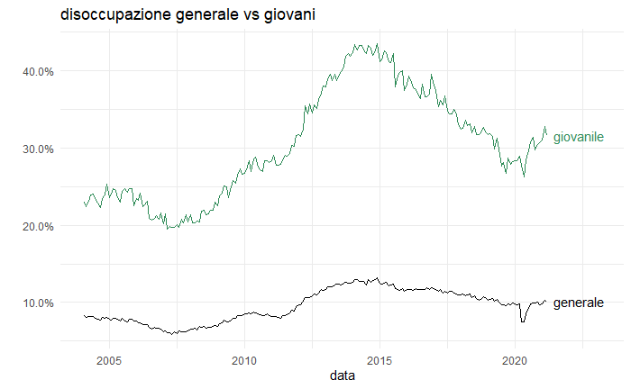

```r
  ggplot(istat_allungato, aes(x=data, y=valore, group=dis, color=dis))+
#pensa a un colore migliore
   scale_color_manual(values=c("black","seagreen"), guide="none")+
   geom_line()+ #aes(linetype=Sesso) potevi metterlo pure qui dentro
 geom_text( aes( label=dis) ,data=rightmost, show.legend=FALSE, hjust=0, nudge_x = 100)+


  ggtitle("disoccupazione generale vs giovani")+
  ylab("")+
  scale_y_continuous(labels = scales::percent_format())+
 # scale_y_continuous è la scala di default per l'estetica y. labels è un parametro
scale_x_date(expand=expansion(mult = c(0.05,0.15)))+
    #0.05 per lato sx, 0.15 per lato dx. HO allungato del 15% a destra l'asse delle x e del 5% a sx
  theme_minimal()
```

```r
  #in ottica esame, richiesto un lavoro ben curato. Etichette si devono leggere, non devono essere tagliate
```

## Annotazioni

- Modificare il grafico precedente in modo da mostrare il valore massimo, il valore minimo ed il valore finale (assieme alla *direct label*) di ciascuna serie.

```r
## DA COMPLETARE
 percentuale<- function(num){
     r<- paste0(round((num*100),1), "%")
 }



riassunto<-istat_allungato%>%
  group_by(dis)%>%
  summarise(massimo=max(valore), minimo=min(valore), disoccupazione=last(valore), data=last(data))

riassunto
```

| dis | massimo | minimo | disoccupazione | data |
| --- | --- | --- | --- | --- |
| generale | 0.1325777 | 0.05886569 | 0.1022466 | 2021-02-28 |
| giovanile | 0.4343668 | 0.19443469 | 0.3156687 | 2021-02-28 |

```r
#poi non l'ho piu usato questo riassunto

max_d<-istat_allungato%>%
  group_by(dis)%>%
  filter(valore==max(valore))

max_d
```

| anno | mese | Sesso | data | attivita | occupazione | dis | valore |
| --- | --- | --- | --- | --- | --- | --- | --- |
| 2014 | Novembre | MF | 2014-11-30 | 0.6404498 | 0.5542415 | generale | 0.1325777 |
| 2014 | Novembre | MF | 2014-11-30 | 0.6404498 | 0.5542415 | giovanile | 0.4343668 |

```r
min_d<-istat_allungato%>%
  group_by(dis)%>%
  filter(valore==min(valore))

min_d
```

| anno | mese | Sesso | data | attivita | occupazione | dis | valore |
| --- | --- | --- | --- | --- | --- | --- | --- |
| 2007 | Febbraio | MF | 2007-02-28 | 0.6205633 | 0.5823925 | giovanile | 0.19443469 |
| 2007 | Aprile | MF | 2007-04-30 | 0.6193189 | 0.5824086 | generale | 0.05886569 |

```r
#DUBBIO. C'è UN MODO PER AGGIUNGERNE UNO SOLO?
istat_allungato
```

| anno | mese | Sesso | data | attivita | occupazione | dis | valore |
| --- | --- | --- | --- | --- | --- | --- | --- |
| 2004 | Gennaio | MF | 2004-01-31 | 0.6251241 | 0.5726618 | generale | 0.08318213 |
| 2004 | Gennaio | MF | 2004-01-31 | 0.6251241 | 0.5726618 | giovanile | 0.23024666 |
| 2004 | Febbraio | MF | 2004-02-29 | 0.6246365 | 0.5738719 | generale | 0.08059644 |
| 2004 | Febbraio | MF | 2004-02-29 | 0.6246365 | 0.5738719 | giovanile | 0.22437874 |
| 2004 | Marzo | MF | 2004-03-31 | 0.6280778 | 0.5760631 | generale | 0.08194947 |
| 2004 | Marzo | MF | 2004-03-31 | 0.6280778 | 0.5760631 | giovanile | 0.23135172 |
| 2004 | Aprile | MF | 2004-04-30 | 0.6229403 | 0.5717253 | generale | 0.08147783 |
| 2004 | Aprile | MF | 2004-04-30 | 0.6229403 | 0.5717253 | giovanile | 0.23898487 |
| 2004 | Maggio | MF | 2004-05-31 | 0.6275064 | 0.5756755 | generale | 0.08166989 |
| 2004 | Maggio | MF | 2004-05-31 | 0.6275064 | 0.5756755 | giovanile | 0.23997998 |

[output cut: 402 more lines]

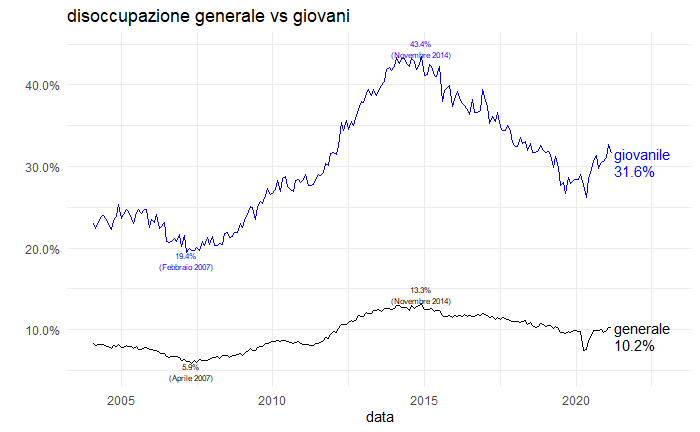

```r
 ggplot(istat_allungato, aes(x=data, y=valore, group=dis, color=dis))+
#pensa a un colore migliore
   scale_color_manual(values=c("black","blue"), guide="none")+
   geom_line()+ #aes(linetype=Sesso) potevi metterlo pure qui dentro
       geom_text(aes(label=dis), data=rightmost, show.legend = FALSE,hjust=0, nudge_x = 40 )+
#geom_text dava problemi, diceva infatti che non vedeva valore
   #in effetti lui prima non aveva aes y e quindi modellava y su valore (scritto a livello globale all'inizio). Valore in riassunto non esiste
   #gli dico che y lo modella su disoccupazione (ovvero l'ultimo valore della serie) cosi lo mette in corrispondenza della y dell'ultimo valore

   #l'ho poi tolta perche ho cambiato dati che usavo, ho deciso di semplicemente filtrare la tabella con le righe col massimo e col minimo
   #essendo le righe uguali, x e y li eredita da sopra
 geom_text( aes( label=percentuale(valore)) ,data=rightmost, show.legend=FALSE, hjust=0, nudge_x = 40, nudge_y = -0.02)+
       geom_text(aes( label=paste0(percentuale(valore),"\n(",mese," ",anno,")")),
         #qui ho concatenato tante stringhe con paste0
                 data=max_d, show.legend = FALSE,hjust=0.5, nudge_y = 0.01, size=2)+
    geom_text(aes( label=paste0(percentuale(valore),"\n(",mese," ",anno,")")), data=min_d, show.legend = FALSE,hjust=0.5, nudge_y = -0.01,size=2)+



  ggtitle("disoccupazione generale vs giovani")+
  ylab("")+
  scale_y_continuous(labels = scales::percent_format(), expand=expansion(mult=c(0.05,0.05)))+
 # scale_y_continuous è la scala di default per l'estetica y. labels è un parametro
scale_x_date(expand=expansion(mult = c(0.05,0.15)))+
  theme_minimal()
```

```r
NA
NA
NA
```

## Aprossimazioni

- Scrivere una funzione che dato un vettore `v` di numeri ed un intero `n`, produca un vettore (di pari lunghezza) contenente la media mobile su `n` elementi. Visto che la media mobile non è definita per i primi $n/2$ elementi, il risultato deve contenere $\lfloor{(n-1)/2}\rfloor$ valori `NA` in testa e $\lfloor{n/2}\rfloor$ `NA` in coda.

| **v** | 2 | 5 | 2 | 6 | 6 | 6 | 3 | 4 | 1 | 6 |
| --- | --- | --- | --- | --- | --- | --- | --- | --- | --- | --- |
| **media mobile** | NA | 3 | 4.333 | 4.667 | 6 | 5 | 4.333 | 2.667 | 3.667 | NA |

```r
## DA COMPLETARE
media_mobile<-function(v,n){
  stopifnot(length(v)>=n)
  #se mi dai vettore di 2 e vuoi media mobile di 3, non va bene
  res=rep(NA,floor((n-1)/2))
  #metto una serie di NA
  while(length(v)>=n){
    res=c(res, mean(v[1:n]))
    v=tail(v,-1)
    #v=v[2: length(v)]
    #lo accorcio di uno togliendo il primo elemento
  }
  res=c(res, rep(NA,floor(n/2)))
  return(res)
}
```

- Rappresentare l’andamento della disoccupazione giovanile con aggiunta la media mobile a tre mesi. I giovani sono pochi. Una piccola variazione nel campione implica una grossa variazione in cio che vediamo. Istat ricordiamo lavora sui campioni.Usiamo allora una media mobile

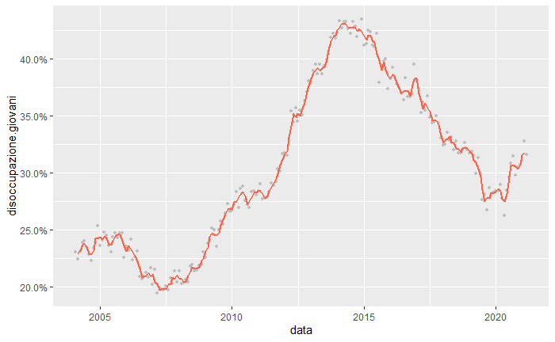

```r
## DA COMPLETARE


istat%>%filter(Sesso=="MF")%>%
  ggplot(aes(x=data, y=disoccupazione.giovani))+
  geom_point(color="gray",size=1)+
  geom_line(aes(y=media_mobile(disoccupazione.giovani,3)),color="tomato",size=1)+
  scale_y_continuous(labels=scales::label_percent())
```

```r
NA
```

- Rappresentare l’andamento della disoccupazione giovanile con aggiunta l’interpolazione LOESS, tramite la funzione `geom_smooth()`.

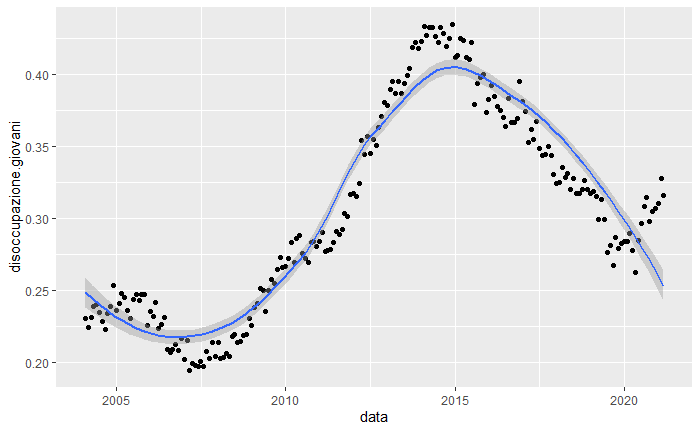

```r
## DA COMPLETARE
istat%>%
  filter(Sesso=="MF")%>%
  ggplot(aes(x=data, y=disoccupazione.giovani))+
  geom_point()+
  geom_smooth(method="loess")
```

## Valori derivati

Dalla [nota metodologica ISTAT](https://www.istat.it/it/files//2021/04/CS_Occupati_disoccupati_FEBBRAIO_2021.pdf) sappiamo che

- Occupati: persone (15-89 anni) che hanno lavorato o sono in permesso
- Disoccupati: persone (15-74 anni) che sono in cerca di lavoro
- Popolazione: persone nella fascia d’età considerata
- Attivi: Occupati + Disoccupati

Il tasso di attività è dato da:

$$t_A = \frac{Attivi}{Popolazione}$$

Il tasso di occupazione è dato da:

$$t_O = \frac{Occupati}{Popolazione}$$

Il tasso di disoccupazione è dato da:

$$t_D = \frac{Disoccupati}{Attivi}$$

A partire dai valori precedenti definiti e forniti dall’ISTAT quindi possiamo calcolare:

La proporzione di disoccupati sulla popolazione totale:

$$p_D = \frac{Disoccupati}{Popolazione} = t_D \cdot t_A$$

La proporzione di inattivi (non attivi) sulla popolazione totale.

$$p_I = \frac{Inattivi}{Popolazione} = 1 - t_A$$

Le popolazionie di riferimento per Occupati e Disoccupati non sono esattamente le stesse, ma la differenza è minima, perciò abbiamo:

$$p_D + t_O + p_I \approx 1$$

- Verificare che la distribuzione della somma tra Tasso di Occupazione, Proporzione di Disoccupati e Proporzione Inattivi sia circa 1 (usando un boxplot) per M, F e MF.

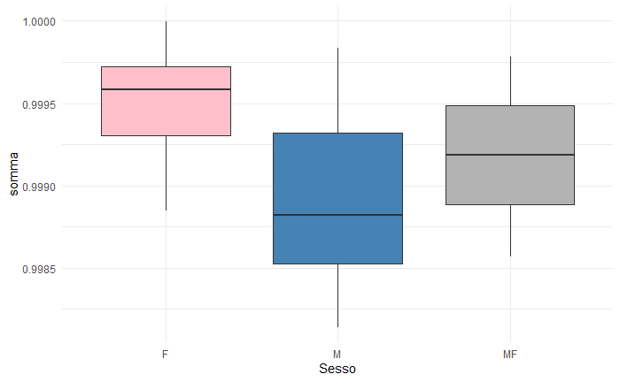

```r
## DA COMPLETARE
r<-istat$disoccupazione*istat$attivita
k<-(1-istat$attivita)

istat%>%
  mutate(prop_disoccupati=r, prop_inattivi=k)%>%
  mutate(somma=prop_disoccupati+prop_inattivi+occupazione)%>%
  ggplot(aes(y=somma, x=Sesso, fill=Sesso))+
  scale_fill_manual(values = c( "pink","steelblue","grey70"), guide="none")+
  geom_boxplot()+
  theme_minimal()
```

```r
NA
NA
NA
```

**Riflessione** lo scostamento è dovuto alla non esatta corrispondenza tra le popolazioni, in particolare è tanto più ampio quando più c’è una parte di occupati nella popolazione tra 74 e 89 anni.

- Modificare il diagramma precedente usando un violin plot sopra il quale riportare i punti relativi ai singoli valori.
  - usare il parametro `position="jitter"` per sparpagliare in maniera casuale i punti, evitando così di averli tutti allineati e sovrapposti.

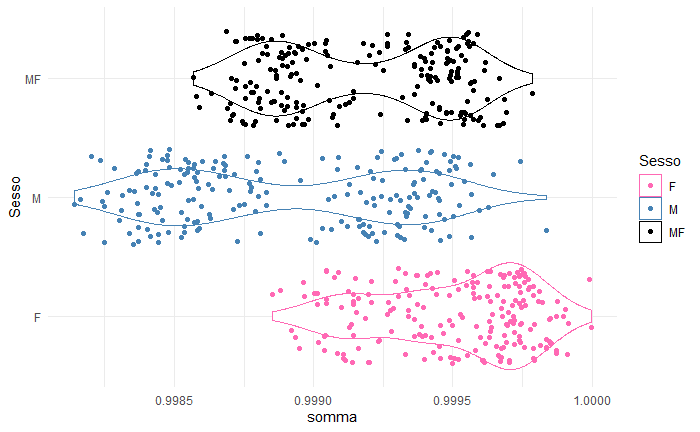

```r
## DA COMPLETARE

istat%<>%
  mutate(prop_disoccupati=r, prop_inattivi=k)%>%
  mutate(somma=prop_disoccupati+prop_inattivi+occupazione)

istat%>%
  ggplot(aes(x=somma, y=Sesso, color=Sesso))+
  scale_color_manual(values = c( "hotpink","steelblue","black"))+
  geom_violin()+
  #senza il jitter sono tutti sulla stessa linea e non sapresti distinguere dove ce ne sono di piu e dove di meno
  geom_point(position = "jitter")+
  theme_minimal()
```

```r
#boxplot piu semplice, ma ci nasconde molti dettagli che qui invece vediamo
```

- Mostrare con un diagramma ad area l’andamento delle tre componenti della somma nel corso del periodo di osservazione per la popolazione generale (MF).

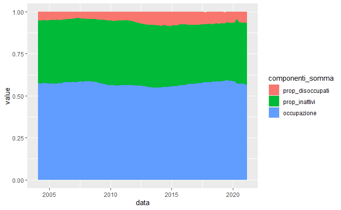

```r
## DA COMPLETARE
istat%>%
  filter(Sesso=="MF")%>%
  pivot_longer(cols=c("prop_disoccupati","prop_inattivi", "occupazione"), names_to = "componenti_somma")%>%
  select(-somma)%>%
  mutate(componenti_somma=as_factor(componenti_somma))%>%
  ggplot(aes(x=data, y=value, fill=componenti_somma))+
  geom_area()
```

```r
NA
NA
```